# R Coding VI: Exploratory Data Visualization

Fred LaPolla

7/23/2020

# Data Visualization

# Objectives

Students will be able to:

- Explore their data to visually assess skew
- Create a heatmap to visually assess gene expression levels
- Use Ggplot2 to build different types of charts by employing layers
- Create charts and figures for publication including customzing colors and shapes, as well as exporting figures from R.

# Getting started

Let’s pull in our same NYC HANES data set.

```r
library(RCurl)
url <-getURL("https://raw.githubusercontent.com/fredwillie/RScience2020/master/NYC_HANES_DIAB.csv")
nyc <- read.csv(text = url)
nyc <- na.omit(nyc)
nyc$AGEGROUP <- factor(nyc$AGEGROUP, levels = 1:3, labels = c("Youngest", "Middle", "Aged"))
nyc$GENDER <- factor(nyc$GENDER, levels = 1:2, labels = c("male", "female"))
# Rename the HSQ_1 factor for identification
  nyc$HSQ_1 <- factor(nyc$HSQ_1, levels = 1:5, labels=c("Excellent","Very Good","Good", "Fair", "Poor"))
  # Rename the DX_DBTS as a factor
  nyc$DX_DBTS <- factor(nyc$DX_DBTS,levels = 1:3, labels=c("Diabetes with DX","Diabetes with no DX","No Diabetes"))
```

There are two major reasons we might want to visualize our data: exploration and communication.

# Data Exploration

In the first class, what were some of the ways we discussed to get a sense of our data? Why do we do this?

- Summary
- paste.ecs::stat.desc
- psych::describe
- Others

In addition to getting an understanding of our data, these tools help us understand what sort of tests are possible on our data type.

# Data Exploration

One of the first things we may want to know is “Is my data normally distributed”? Why might we want to know this?

- Different statistical tests for hypothesis testing assume a Gaussian or Normal Distribution
- A quick way to get a sense of the nature of our distribution is to look at a picture, and a common option is a **Histogram**

# Data Exploration

The command hist() let’s us make a histogram:

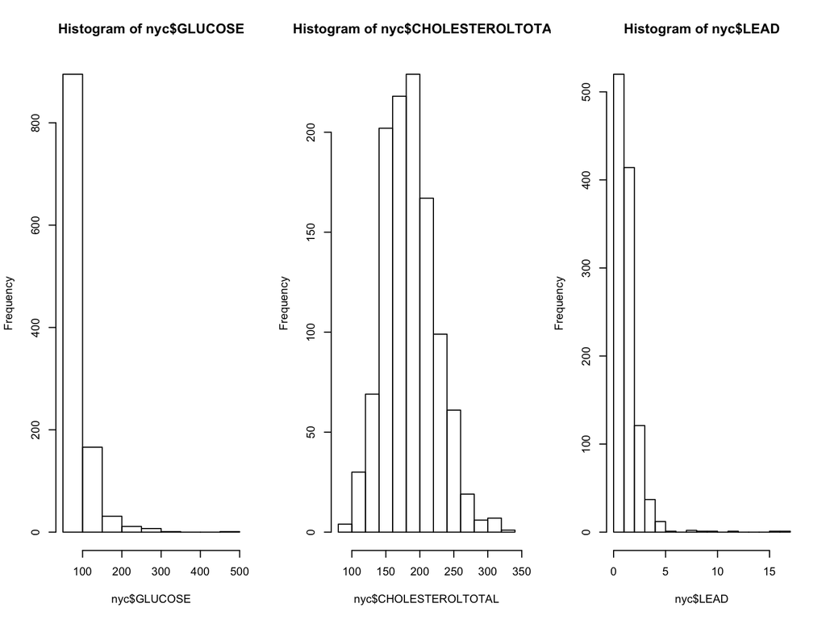

```r
#For today don't worry about par, this is to plot three charts side by side
threechart <-par(mfrow = c(1,3))
#this is the meat of the matter
hist(nyc$GLUCOSE)

hist(nyc$CHOLESTEROLTOTAL)

hist(nyc$LEAD)
```

```r
par(mfrow = c(1,1))
```

# Hist colors

You could also give it a fill if you want:

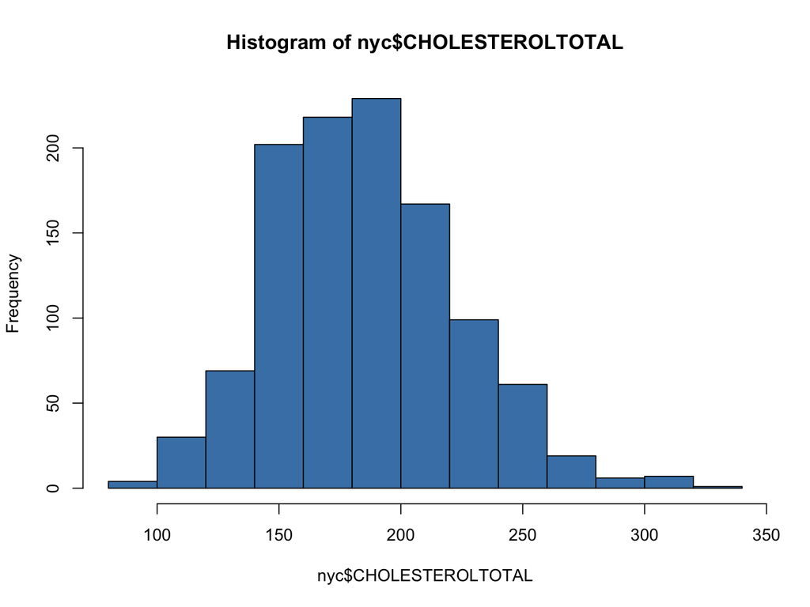

```r
hist(nyc$CHOLESTEROLTOTAL, col = "steelblue")
```

# Group Work

Try to make a histogram of MERCURYU and LDL Estimate. Are these normally distributed or skewed, and if so, which way?

# Boxplot

We can also use boxplots, sometimes also called Box and Whisker or Tukey plots.

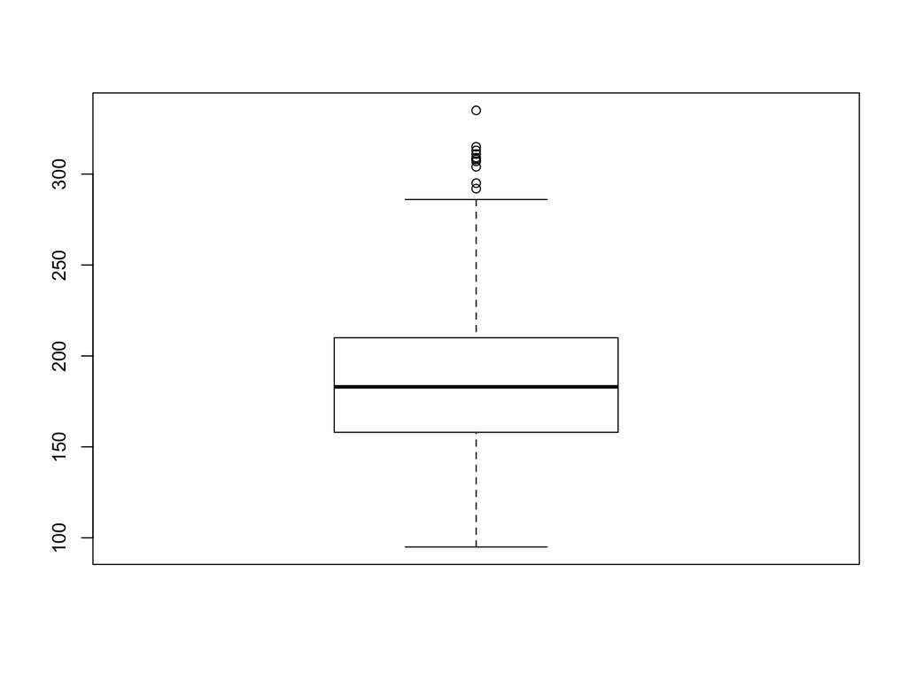

```r
boxplot(nyc$CHOLESTEROLTOTAL)
```

# Boxplots

You can also use boxplots to look at comparisons of groups.

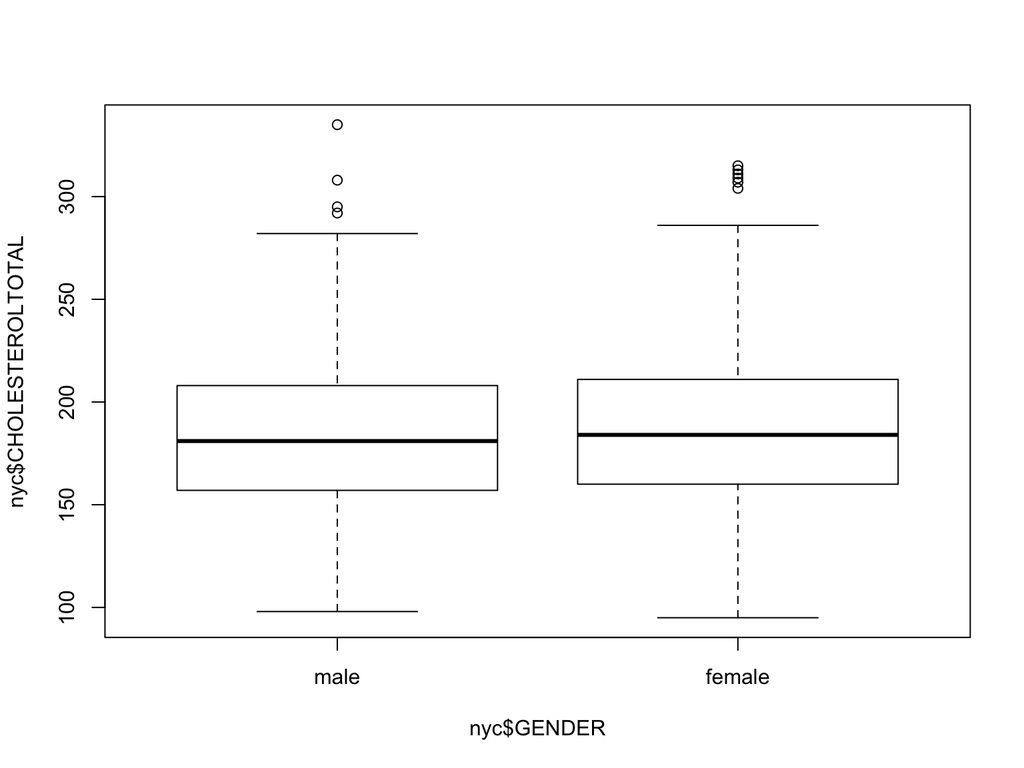

```r
boxplot(nyc$CHOLESTEROLTOTAL ~ nyc$GENDER)
```

# Boxplots

You can also add in a notch, which if the notch overlaps is a good rule of thumb that they are not statistically significantly different (but beware of statistical significance).

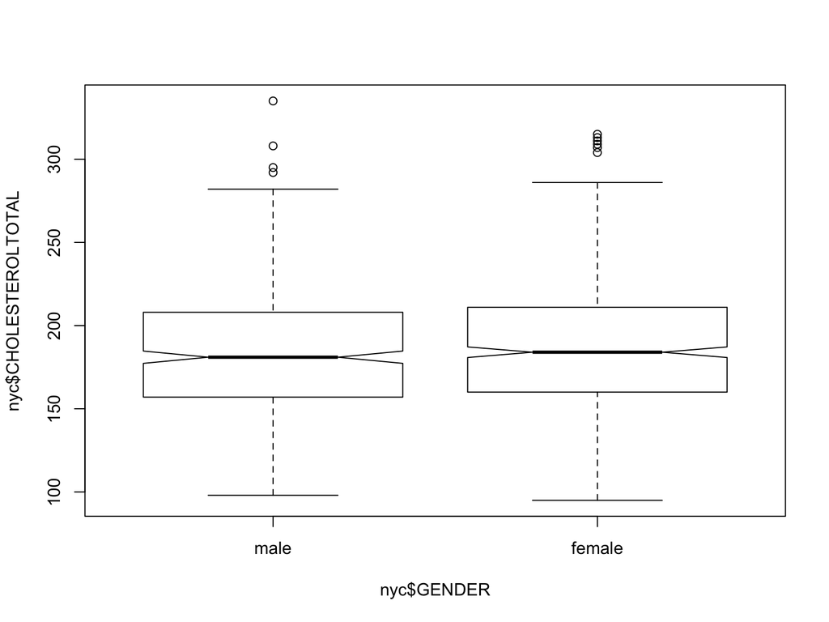

```r
boxplot(nyc$CHOLESTEROLTOTAL ~ nyc$GENDER, notch = TRUE)
```

# Boxplots

With a color

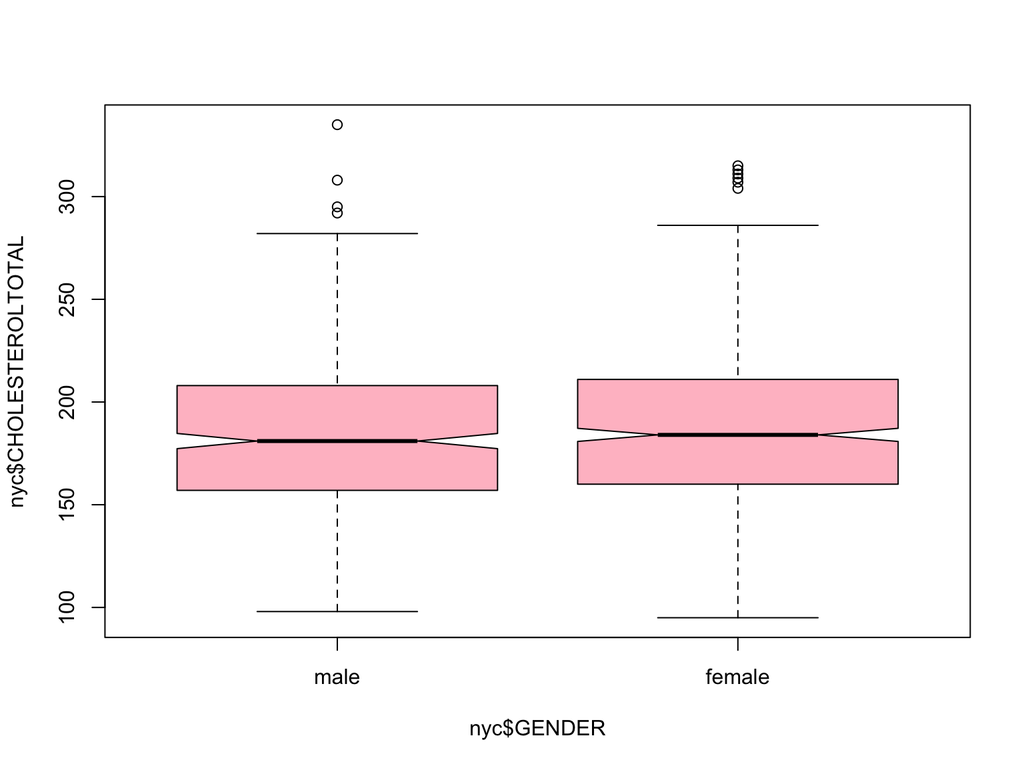

```r
boxplot(nyc$CHOLESTEROLTOTAL ~ nyc$GENDER, notch = TRUE, col = "pink")
```

# Group Work

Make a box plot of A1C by diabetes diagnosis. Are they likely the same for both groups?

# QQ Plots

Another option for looking at skew is the Quantile-Quantile Plot, or QQ Plot. This chart plots quantiles, similar to percentiles of our data against a normally distributed quantile. Baiscally, the more our data lies on a straight line, the more normal it is. Compare:

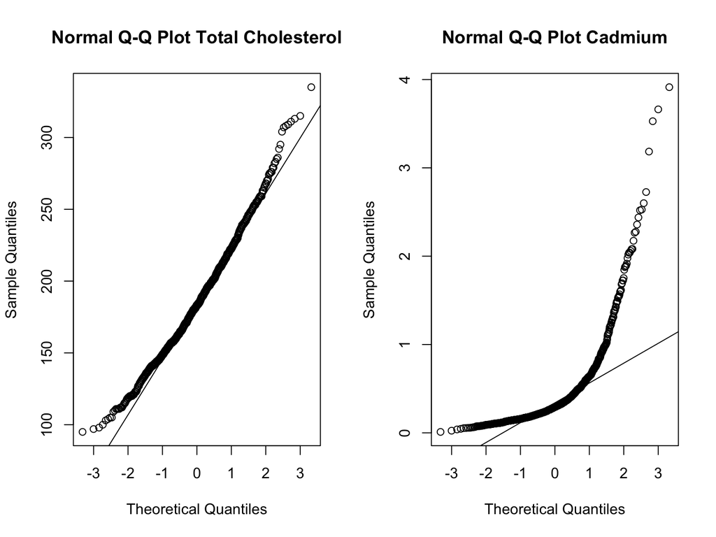

```r
#QQNorm plots how the quantiles of our sample compare to a theoretical normal distribution
par(mfrow=c(1,2))
##QQPlot for total cholesterol
qqnorm(nyc$CHOLESTEROLTOTAL, main = "Normal Q-Q Plot Total Cholesterol")
#QQLine adds a straight line for reference
qqline(nyc$CHOLESTEROLTOTAL)

##QQPlot for Cadmium
qqnorm(nyc$CADMIUM,main= "Normal Q-Q Plot Cadmium")
qqline(nyc$CADMIUM)
```

# Group Work

Make a qq plot of LDL. Also make one for MercuryU. Would you expect either of these to be normal or skewed? How can you tell?

# Correlations & Scatter Plots

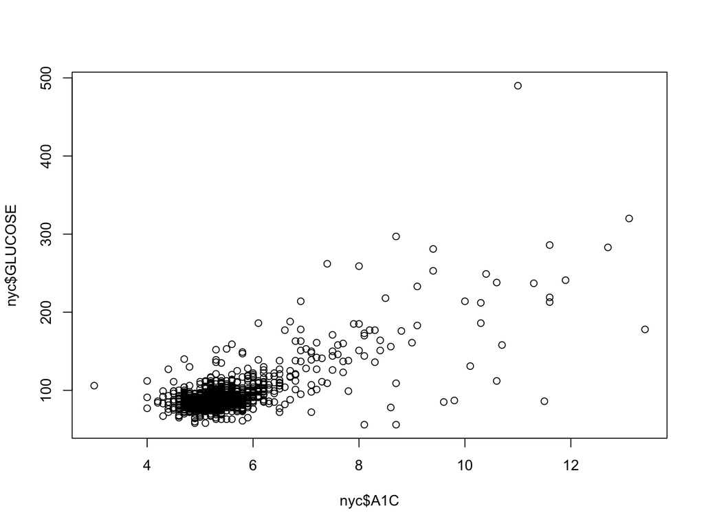

```r
plot(nyc$A1C, nyc$GLUCOSE)
```

```r
wilcox.test(nyc$A1C, nyc$GLUCOSE, paired = TRUE, alternative = "two.sided")
```

```
##
##  Wilcoxon signed rank test with continuity correction
##
## data:  nyc$A1C and nyc$GLUCOSE
## V = 0, p-value < 2.2e-16
## alternative hypothesis: true location shift is not equal to 0
```

# Correlation & Scatter Plots

Sometimes, for example in cases where our scale has exponentially larger outliers, it can be helpful to try to normalize our data so that the chart is more viewable. You could try a transformation like “log()”. It is helpful to do the log +1 in this case because log(0) is negative infinity

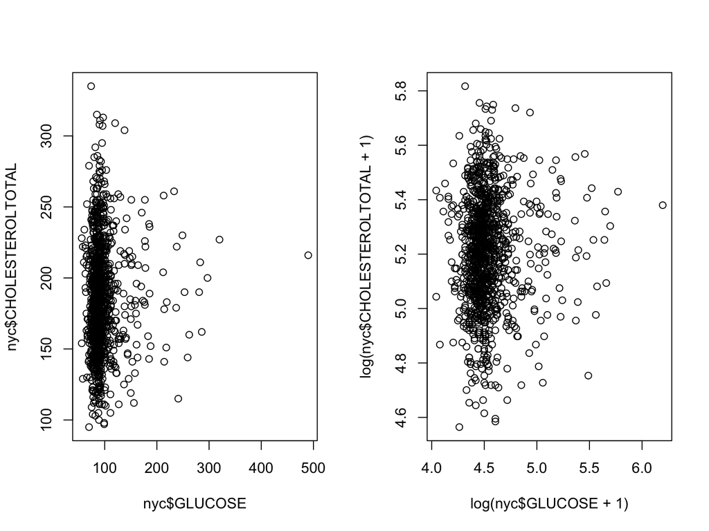

```r
par(mfrow = c(1,2))
plot(nyc$GLUCOSE, nyc$CHOLESTEROLTOTAL)
plot(log(nyc$GLUCOSE+1), log(nyc$CHOLESTEROLTOTAL+1))
```

# Group Work

If we wanted to make a scatter plot of lead by cotinine, how would we do it? Based on what you now know about assessing skew, what test might we run for this?